# Filtering Data

`L0~gs.`api`.log.57_13-09-2019_06:59 34703 INFO gs.`openstack.wsgi.server `[ req-y9mjwk-n1yj-6wl35r-nhwlbg ]`HTTP exception thrown: No entry found for any event

The `highlighted` text does not provide intuition about the log hence should be removed

## Input

`L0~gs.`api`.log.57_13-09-2019_06:59 34703 INFO gs.`openstack.wsgi.server `[ req-y9mjwk-n1yj-6wl35r-nhwlbg ]`HTTP exception thrown: No entry found for any event

## output

**api , openstack wsgi server , HTTP exception thrown No entry found for any event**

```python
import re
log=[]
f_new= open("new2.txt",'w')
with open("private_test_set.txt") as f:
    for line in f:
        idx=line.find("~gs")
        if idx!=-1:
            new=line[idx+4:]
        idx1=new.find(".log")
        idx2=new.find("INFO")
        if idx1!=-1 and idx2!=-1:
            new=new[:idx1]+" "+new[idx2+8:]
        new=new.replace("] [","*")
        idx1=new.find("[")
        idx2=new.find("]")
        if idx1!=-1 and idx2!=-1:
            new=new[:idx1]+" "+new[idx2+1:]
        idx=new.find("status:")
        if idx!=-1:
            new=new[:idx]
        new = re.sub('[^a-zA-Z \n\ ]', ' ', new)
        print(new , file=f_new)

f_new.close()
```

# Features

the useful words will act as features of log `features` is a list of useful word (space seperated string) in log

features[i] denotes ith line of log

```python
features=[]
with open("new2.txt","r") as f:  # opening the saved file
    for i in f:
        if i!="\n":
            features+=[" ".join(i.split())]
```

```python
len(features)
```

```
1050
```

# Count Vecterization

as computer only understands numbers,so we will convert words to integers makes one hot encoding of words in ith string

```python
from sklearn.feature_extraction.text import CountVectorizer
vectorizer = CountVectorizer()
X_ = vectorizer.fit_transform(features)
```

```python
print((len(vectorizer.get_feature_names())))
```

```
686
```

# Dimention Reduction

as we have extra features which dont contribute in classification we will decrease its dimentions to 10.

Here we will use **autoencoder** to decrease dimentionality

## AutoEncoder

An autoencoder is a neural network that learns to copy its input to its output. It has an internal (hidden) layer that describes a code used to represent the input, and it is constituted by two main parts: an encoder that maps the input into the code, and a decoder that maps the code to a reconstruction of the original input.

This is why usually autoencoders are restricted in ways that force them to reconstruct the input only approximately, prioritizing the most relevant aspects of the data to be copied.

```python
%pylab inline
import os
import keras
import metrics
import numpy as np
import pandas as pd
import keras.backend as K

from time import time

from keras import callbacks
from keras.models import Model
from keras.optimizers import SGD
from keras.layers import Dense, Input
from keras.initializers import VarianceScaling
from keras.engine.topology import Layer, InputSpec

# from scipy.misc import imread
from sklearn.cluster import KMeans
from sklearn.metrics import accuracy_score, normalized_mutual_info_score
```

```python
# this is our input placeholder
input_ = Input(shape=((len(vectorizer.get_feature_names())),))

encoded = Dense(10, activation='sigmoid')(input_)

decoded = Dense((len(vectorizer.get_feature_names())))(encoded)

# this model maps an input to its reconstruction
autoencoder = Model(input_, decoded)
```

```python
autoencoder.summary()
```

```
Model: "model_38"
_________________________________________________________________
Layer (type)                 Output Shape              Param #
=================================================================
input_23 (InputLayer)        (None, 686)               0
_________________________________________________________________
dense_117 (Dense)            (None, 10)                6870
_________________________________________________________________
dense_118 (Dense)            (None, 686)               7546
=================================================================
Total params: 14,416
Trainable params: 14,416
Non-trainable params: 0
_________________________________________________________________
```

```python
encoder = Model(input_, encoded)
```

```python
autoencoder.compile(optimizer='adam', loss='mse')
```

Here epoch and batch size are calculated on the basis of trail and error method

```python
train_history = autoencoder.fit(X_, X_, epochs=500, batch_size=1024)
```

```python
X_new=encoder.predict(X_)
```

```python
X_new.shape
```

```
(1050, 10)
```

The new dimentions are 10

# K Means Clusttring

Now we will use kmeans clustering

K-means clustering is one of the simplest and popular unsupervised machine learning algorithms.

The objective of K-means is simple: group similar data points together and discover underlying patterns. To achieve this objective, K-means looks for a fixed number (k) of clusters in a dataset

## Elbow Method for optimal value of k in KMeans

```python
from scipy.spatial.distance import cdist
distortions = []
inertias = []
mapping1 = {}
mapping2 = {}
X=X_new
for k in range(5,21):
    #Building and fitting the model
    kmeanModel = KMeans(n_clusters=k).fit(X)
    kmeanModel.fit(X)

    distortions.append(sum(np.min(cdist(X, kmeanModel.cluster_centers_,
                      'euclidean'),axis=1)) / X.shape[0])
    inertias.append(kmeanModel.inertia_)

    mapping1[k] = sum(np.min(cdist(X, kmeanModel.cluster_centers_,
                 'euclidean'),axis=1)) / X.shape[0]
    mapping2[k] = kmeanModel.inertia_
```

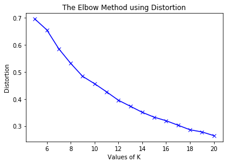

```python
plt.plot(range(5,21), distortions, 'bx-')
plt.xlabel('Values of K')
plt.ylabel('Distortion')
plt.title('The Elbow Method using Distortion')
plt.show()
```

```python
km = KMeans(n_jobs=-1, n_clusters=20, n_init=20)
# pred_auto_train = encoder.predict(X_new)
km.fit(X_new)
pred = km.predict(X_new)
```

Stroing prediction in csv file

```python
with open("ans1.csv","w") as f:
    for i in pred:
        print("C"+str(i+1),file=f)
```